# Workshop 4: Example report

Your name here

2023-05-24

This document is a model example of what a report for this assignment might look like. Note that

- The example uses the motorcycle accidents dataset from Colombia, but you should use the India TB dataset.
- Code echo is turned off in all code chunks so that the finished product hides the source code, showing only the output.

# Example Assignment

## Road Injuries of Motorcyclists in Medellín

The dataset analysed in this report provides information about deaths caused by motorcycle accidents in Medellín, a Colombian city. The data is sourced from medical and police certificates and can he access [here](https://zenodo.org/record/4836304).

## Age group distribution per sex group

The two categorical variables I chose to look at are age group and sex.

The plot below shows the age group distributions for each sex:

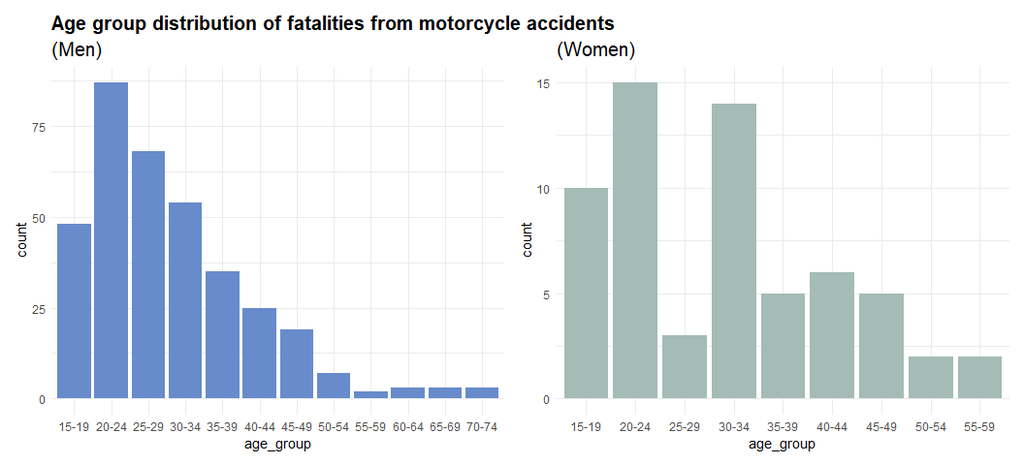

And the table below shows similar information:

Age & gender distribution of fatalities from motorcycle accidents

| age_group | female | male |
| --- | --- | --- |
| 15-19 | 10 | 48 |
| 20-24 | 15 | 87 |
| 25-29 | 3 | 68 |
| 30-34 | 14 | 54 |
| 35-39 | 5 | 35 |
| 40-44 | 6 | 25 |
| 45-49 | 5 | 19 |
| 50-54 | 2 | 7 |
| 55-59 | 2 | 2 |
| 60-64 | 0 | 3 |
| 65-69 | 0 | 3 |
| 70-74 | 0 | 3 |

For both sexes, the age group with the most deaths was the 20 to 24 age group. In women, there were 15 deaths in this age group, and in men there were 87 deaths.

## Areas of improvement

- The two bar charts have different numbers of bars. This is not ideal for comparisons.
- The age group labels are too horizontally compressed.
- I do not yet know how to change the variable names, so I left in the name `age_group` in the table and plot.